# Rate My Professor: is it always bad?

Nathan Cooper Jones

February 21, 2019

The code that fueled my blog post here: https://nathancooperjones.com/rate-my-professor-is-it-always-bad/

# Getting and Cleaning the Data

## Web Scrape Round 1: Show me the professors!

The first web scrape I’ll be doing will start here, where I’ll collect the name, subject, and URL to the reviews page for each professor. One minor challenge was the ability to scrape more than just the first page of 20 professors and not have to “hard-code” a single limit to search until (if the limit is 654 today, next semester it could be 672 and a “hard-coded” limit would be missing out on those newly-added professors). To do this, we just web scrape the total number of results, make it a multiple of 20, and iterate through each multiple of 20 up to that limit, setting the website offset to this to generate a page of new professors.

<sub>* As a quick aside: I used Jake Daniel’s wonderful web-scraping R code template you can read more about here (https://datacritics.com/2018/03/20/scrape-it-yourself-spotify-charts/) and the Google Chrome tool SelectorGadget found here (https://chrome.google.com/webstore/detail/selectorgadget/mhjhnkcfbdhnjickkkdbjoemdmbfginb) to make this a bit easier on myself. With that, we’ll start our journey at the RMP professor search page for my university, Illinois Institute of Technology.</sub>

```r
# URL with the offset field at the end left blank - we'll add on to that soon.
url <- "http://www.ratemyprofessors.com/search.jsp?query=illinois+institute+of+technology&queryoption=HEADER&stateselect=&country=&dept=&queryBy=teacherName&facetSearch=true&schoolName=illinois+institute+of+technology&offset="

how_many <- url %>% read_html() %>% html_nodes('.result-count') %>% html_text() %>% as.data.frame()

# we now have a data table with two rows - the first is garbage from the RMP website while
# the second is the actual sentence we want "Showing 1-20 results of ??..."
showing_results <- how_many[2, ] # keep only the relevant sentence
showing_results_but_no_showing <- sub(".* of ", "", showing_results) # Get rid of everything after the word 'of'
max_number <- parse_number(showing_results_but_no_showing) # Extract the integer

num_offsets <- max_number - (max_number %% 20) # Make it a multiple of 20

offset_values <- seq(0, num_offsets, by = 20) # Generate a sequence of multiples of 20s to the limit

unitedata<- function(x) {
  full_url <- paste0(url, x)
  full_url
}

finalurl <- unitedata(offset_values) # Create all the URLs with different offset values that we will scrape from

rmp_scrape_for_links <- function(x) {
  page <- x
  name <- page %>% read_html() %>% html_nodes('.main') %>% html_text() %>% as.data.frame(stringsAsFactors = FALSE)
  url <- page %>% read_html() %>% html_nodes('.PROFESSOR a') %>% html_attr('href') %>% as.data.frame(stringsAsFactors = FALSE)
  subject <- page %>% read_html() %>% html_nodes('.sub') %>% html_text() %>% as.data.frame(stringsAsFactors = FALSE)

  # Combine the features, name them, return them, then rest :)
  links <- cbind(name, url, subject)
  names(links) <- c("Name", "URL", "Subject")
  return(links)
}
professor_links <- map_df(finalurl, rmp_scrape_for_links)
head(professor_links)
```

```
##               Name                         URL
## 1     Stagliano,   /ShowRatings.jsp?tid=125537
## 2         Poros,   /ShowRatings.jsp?tid=495895
## 3   Saniie, Jafar   /ShowRatings.jsp?tid=54696
## 4 Ginsburg, Issac  /ShowRatings.jsp?tid=118862
## 5    Lee, Michael  /ShowRatings.jsp?tid=125289
## 6  Miranda, Jesus  /ShowRatings.jsp?tid=125291
##                                              Subject
## 1          Illinois Institute of Technology, Science
## 2        Illinois Institute of Technology, Sociology
## 3      Illinois Institute of Technology, Engineering
## 4      Illinois Institute of Technology, Engineering
## 5 Illinois Institute of Technology, Computer Science
## 6 Illinois Institute of Technology, Computer Science
```

## Data Cleaning Round 1: This isn’t *that* bad…

```r
first_name <- sub(".*,", "", professor_links$Name) # extract first name
last_name <- sub(",.*", "", professor_links$Name) # extract last name
professor_links$Name <- paste(first_name, last_name) # marry the two
professor_links$Name <- trimws(professor_links$Name) # kill the whitespace
professor_links$URL <- paste0("http://www.ratemyprofessors.com", professor_links$URL) # make it a full url
professor_links$Subject <- sub(".*, ", "", professor_links$Subject) # trim the school name from the subject
professor_links <- unique(professor_links) # remove duplicates
professor_links <- as_tibble(professor_links) # i like tibbles :)

head(professor_links)
```

```
## # A tibble: 6 x 3
##   Name          URL                                           Subject
##   <chr>         <chr>                                         <chr>
## 1 Stagliano     http://www.ratemyprofessors.com/ShowRatings.… Science
## 2 Poros         http://www.ratemyprofessors.com/ShowRatings.… Sociology
## 3 Jafar  Saniie http://www.ratemyprofessors.com/ShowRatings.… Engineering
## 4 Issac  Ginsb… http://www.ratemyprofessors.com/ShowRatings.… Engineering
## 5 Michael  Lee  http://www.ratemyprofessors.com/ShowRatings.… Computer Sci…
## 6 Jesus  Miran… http://www.ratemyprofessors.com/ShowRatings.… Computer Sci…
```

## Web Scrape Round 2: This might take a while…

Our objective is now clear: copy and paste what we just did above with our web scraper and use it again to get individual ratings for each of the URLs in our dataframe. Sounds simple, but it does take a while to run since we’ll be scraping all information we possibly can for each rating. If you listen to The Allman Brothers’ song “Mountain Jam” while this runs - it’ll be over before the song is, guranteed!

```r
rmp_scrape_for_ratings <- function(x) {
  page <- x
  name <- page %>% read_html() %>% html_nodes('.profname') %>% html_text() %>% as.data.frame(stringsAsFactors = FALSE)
  course <- page %>% read_html() %>% html_nodes('.name .response') %>% html_text() %>% as.data.frame(stringsAsFactors = FALSE)
  rating <- page %>% read_html() %>% html_nodes('.rating-type') %>% html_text() %>% as.data.frame(stringsAsFactors = FALSE)
  overall_quality <- page %>% read_html() %>% html_nodes('.break:nth-child(1) .score') %>% html_text() %>% as.data.frame(stringsAsFactors = FALSE)
  difficulty_level <- page %>% read_html() %>% html_nodes('.inverse') %>% html_text() %>% as.data.frame(stringsAsFactors = FALSE)
  comments <- page %>% read_html() %>% html_nodes('.commentsParagraph') %>% html_text() %>% as.data.frame(stringsAsFactors = FALSE)
  tags <- page %>% read_html() %>% html_nodes('.tagbox') %>% html_text() %>% as.data.frame(stringsAsFactors = FALSE)
  helpful <- page %>% read_html() %>% html_nodes('.helpful .count') %>% html_text() %>% as.data.frame(stringsAsFactors = FALSE)
  nothelpful <- page %>% read_html() %>% html_nodes('.nothelpful .count') %>% html_text() %>% as.data.frame(stringsAsFactors = FALSE)
  grade <- page %>% read_html() %>% html_nodes('.grade .response') %>% html_text() %>% as.data.frame(stringsAsFactors = FALSE)
  take_again <- page %>% read_html() %>% html_nodes('.would-take-again .response') %>% html_text() %>% as.data.frame(stringsAsFactors = FALSE)
  textbook <- page %>% read_html() %>% html_nodes('.textbook-used .response') %>% html_text() %>% as.data.frame(stringsAsFactors = FALSE)
  attendance <- page %>% read_html() %>% html_nodes('.attendance .response ') %>% html_text() %>% as.data.frame(stringsAsFactors = FALSE)
  for_credit <- page %>% read_html() %>% html_nodes('.credit .response ') %>% html_text() %>% as.data.frame(stringsAsFactors = FALSE)
  date <- page %>% read_html() %>% html_nodes('.date  ') %>% html_text() %>% as.data.frame(stringsAsFactors = FALSE)
  name_rep <- rep(name$.[1], nrow(rating))

  if (nrow(course) == 0) {
    return() # no empty dataframes!
  }

  # combining, naming, classifying our variables
  ratings <- cbind(name_rep, course, rating, overall_quality, difficulty_level, comments, tags, helpful, nothelpful, grade,
                   take_again, textbook, attendance, for_credit, date)
  ratings[] <- lapply(ratings, as.character)
  names(ratings) <- c("Name", "Course", "Rating", "Quality", "Difficulty", "Comments", "Tags", "NumHelpful", "NumNotHelpful",
                      "Grade", "WouldTakeAgain", "TextbookUsed", "AttendanceRequired", "ForCredit", "Date")
  return(ratings)
}

professor_ratings <- map_df(professor_links$URL, rmp_scrape_for_ratings)
professor_ratings_temp <- professor_ratings # in case I mess it all up permanently...
head(professor_ratings)
```

```
##                                                                            Name
## 1 \r\n                \r\n              Stagliano\r\n            \r\n
## 2 \r\n                \r\n              Stagliano\r\n            \r\n
## 3 \r\n                \r\n              Stagliano\r\n            \r\n
## 4 \r\n                \r\n              Stagliano\r\n            \r\n
## 5 \r\n                \r\n              Stagliano\r\n            \r\n
## 6 \r\n                \r\n              Stagliano\r\n            \r\n
##        Course  Rating Quality Difficulty
## 1     CHEM237 awesome     5.0        3.0
## 2     CHEM531 awesome     5.0        3.0
## 3     CHEM124 awesome     5.0        4.0
## 4 CHEMAMPORGO awesome     5.0        4.0
## 5     CHEM237 awesome     4.5        4.0
## 6    ORGANICI average     3.0        5.0
##                                                                                                                                                                                                                                                                                                          …
```

[output cut: 34 more lines]

## Data Cleaning Round 2: Okay this isn’t great…

Looking at the dataframe we just scraped together, there are a lot of messy values in the columns that can be pretty simply cleaned.

The tags on the other hand… a mess! If a rating has three separate tags listed for a course review, for example “CARING”, “SKIP CLASS? YOU WON’T PASS.”, and “HILARIOUS”, they are listed in the `Tags` column as a single string, “CARING SKIP CLASS? YOU WON’T PASS. HILARIOUS”, which doesn’t lend itself well for analysis. So, rather than having R do it for me automatically like any other analysis, I’m creating dummy variables manually with either `0` or `1` values of whether the tag was in the `Tag` column. Now a computer can read and understand just how good (or bad) professors truly are with tags.

Almost done! The last thing I do here is create a column called `GoodProf` which I’ll be using for analysis a bit later on. The rules are simple: if the quality of the course review is greater than or equal to 3.5, it’s marked as a good professor! If not, it’s a bad one - easy!

<sub>*I took a bit of inspiration on this criteria based on this paper doing something pretty similar: http://web.eecs.umich.edu/~mihalcea/papers/azab.socinfo16.pdf (but I promise, I found it well after my work on this project!).</sub>

```r
## DEFINE HELPER FUNCTIONS ##
numbers_only <- function(x) !grepl("\\D", x) # a fun regular expression to make sure a string is numbers only
floorHundred <- function(x) x - x %% 100

## REMOVE \r\n, excess whitespace, and replace `N/A` with NA ##
for (col in names(professor_ratings)) {
  professor_ratings[[col]] <- gsub("\r\n ", "", professor_ratings[[col]]) # get rid of \r\n in the name
  professor_ratings[[col]] <- gsub("N/A", NA, professor_ratings[[col]]) # make our NAs official!
  professor_ratings[[col]] <- trimws(professor_ratings[[col]]) # trime whitspace
}

## CREATE COURSE NUMBERS AND LEVELS, A SIMPLIFCATION OF COURSE##
# Okay, time to clean up the courses. First, we make sure that the course has a number in it AND it is either 1) strictly numbers or 2) has the word "CS" in it
# If these conditions are true, keep it as is, if not, replace it with 0 (which will represent our "Other" category)
# Put everything in a new column, `Course_Number`
professor_ratings$Course_Number <- ifelse(grepl("\\d", professor_ratings$Course), professor_ratings$Course, 0)
professor_ratings$Course_Number <- gsub("[^0-9]", "", professor_ratings$Course_Number) # parse the number from the course
professor_ratings$Course_Number <- as.numeric(professor_ratings$Course_Number) # Course_Number is numeric or else the next line won't work...

two_courses <- professor_ratings %>%
  filter(Course_Number >= 100000 & Course_Number <= 999999) %>% # capture reviews with two courses attached (six digits total)
  mutate(Course = ".")

two_courses$Course_Number <- as.numeric(as.character(substr(two_courses$Course_Number, 4, 6))) # just get the last three-digit course
professor_ratings$Course_Number <- as.numeric(as.character(substr(professor_ratings$Course_Number, 1, 3))) # just get the first three-digit course
professor_ratings <- rbind(professor_ratings, two_courses) # combine the two :)

# If the course number is less than 100, it doesn't exist at Illinois Tech. This is a section number usually, so throw it out!
# If it's bigger than 999999, it's three courses? Who does that? This is where I draw the line.
professor_ratings$Course_Number <- ifelse(professor_ratings$Course_Number < 100 | professor_ratings$Course_Number > 999999, 0, professor_ratings$Course_Number)
professor_ratings$Course_Level <- ifelse(professor_ratings$Course_Number == 0, -1, floorHundred(as.numeric(professor_ratings$Course_Number))) # make the "Other" category official

## TAGS, MEET DUMMY VARIABLES! ##
all_possible_tags <- c("TOUGH GRADER", "GIVES GOOD FEEDBACK", "RESPECTED", "GET READY TO READ", "PARTICIPATION MATTERS", "SKIP CLASS? YOU WON'T PASS.",
              "LOTS OF HOMEWORK", "INSPIRATIONAL", "BEWARE OF POP QUIZZES", "ACCESSIBLE OUTSIDE CLASS", "SO MANY PAPERS", "CLEAR GRADING CRITERIA",
              "HILARIOUS", "TEST HEAVY", "GRADED BY FEW THINGS", "AMAZING LECTURES", "CARING", "EXTRA CREDIT", "GROUP PROJECTS", "LECTURE HEAVY")
for (tag in all_possible_tags) {
  tag_col <- gsub("([[:punct:]])|\\s+", "_", tag) # replace spaces and punctuation with `_`
  tag_col <- gsub("__", "_", tag_col) # replace __ with _
  tag_df_col <- as.factor(as.numeric(grepl(tag, professor_ratings$Tags)))
  if (length(levels(tag_df_col)) > 1) {
    professor_ratings[[paste0("TAG_", tag_col)]] <- tag_df_col
  }
}

## SETTING DATA TYPES ##
professor_ratings$Rating <- as.factor(professor_ratings$Rating) # make rating a factor
professor_ratings$Quality <- as.numeric(professor_ratings$Quality) # make quality a numeric
professor_ratings$Difficulty <- as.numeric(professor_ratings$Difficulty) # make difficulty a numeric
professor_ratings$NumHelpful <- as.numeric(professor_ratings$NumHelpful)
professor_ratings$NumNotHelpful <- as.numeric(professor_ratings$NumNotHelpful)
professor_ratings$AttendanceRequired <- as.factor(professor_ratings$AttendanceRequired)
professor_ratings$ForCredit <- as.factor(professor_ratings$ForCredit)
professor_ratings$TextbookUsed <- as.factor(professor_ratings$TextbookUsed)
professor_ratings$WouldTakeAgain <- as.factor(professor_ratings$WouldTakeAgain)
professor_ratings$Grade <- as.factor(professor_ratings$Grade)
professor_ratings$Date <- as.Date(professor_ratings$Date, "%m/%d/%Y")

## CREATE TARGET VARIABLE ##
professor_ratings$GoodProf <- as.factor(ifelse(professor_ratings$Quality >= 3.5, 1, 0))

professor_ratings <- as_tibble(unique(professor_ratings)) # i just really like tibbles
head(professor_ratings)
```

```
## # A tibble: 6 x 37
##   Name  Course Rating Quality Difficulty Comments Tags  NumHelpful
##   <chr> <chr>  <fct>    <dbl>      <dbl> <chr>    <chr>      <dbl>
## 1 Stag… CHEM2… aweso…     5            3 Great P… ""             0
## 2 Stag… CHEM5… aweso…     5            3 Profess… ""             0
## 3 Stag… CHEM1… aweso…     5            4 Great P… ""             0
## 4 Stag… CHEMA… aweso…     5            4 Overall… ""             0
## 5 Stag… CHEM2… aweso…     4.5          4 Very ap… ""             0
## 6 Stag… ORGAN… avera…     3            5 Very ha… ""             0
## # … with 29 more variables: NumNotHelpful <dbl>, Grade <fct>,
## #   WouldTakeAgain <fct>, TextbookUsed <fct>, AttendanceRequired <fct>,
## #   ForCredit <fct>, Date <date>, Course_Number <dbl>, Course_Level <dbl>,
## #   TAG_TOUGH_GRADER <fct>, TAG_GIVES_GOOD_FEEDBACK <fct>,
## #   TAG_RESPECTED <fct>, TAG_GET_READY_TO_READ <fct>,
## #   TAG_PARTICIPATION_MATTERS <fct>, TAG_LOTS_OF_HOMEWORK <fct>,
## #   TAG_INSPIRATIONAL <fct>, TAG_BEWARE_OF_POP_QUIZZES <fct>,
## #   TAG_ACCESSIBLE_OUTSIDE_CLASS <fct>, TAG_SO_MANY_PAPERS <fct>,
## #   TAG_CLEAR_GRADING_CRITERIA <fct>, TAG_HILARIOUS <fct>,
## #   TAG_TEST_HEAVY <fct>, TAG_GRADED_BY_FEW_THINGS <fct>,
## #   TAG_AMAZING_LECTURES <fct>, TAG_CARING <fct>, TAG_EXTRA_CREDIT <fct>,
## #   TAG_GROUP_PROJECTS <fct>, TAG_LECTURE_HEAVY <fct>, GoodProf <fct>
```

# Analysis and Visualization

## Nathan - what’s the best (and worst) course?

This task initially stumped me. If a class has a single negative review with quality 1.0 and another class has three negative reviews with quality 1.5, which class is worse? I believe the latter, but how can we quantify this? The answer is, actually, through IMDb, believe it or not.

**IMDb’s True Bayesian Rating**:

Weighted Rating (WR) =
$$(\frac{v}{v+m} · R) + (\frac{m}{v+m} · C)$$
, where:

- R = average for the movie (mean) = (Rating)
- v = number of votes for the movie = (votes)
- m = minimum votes required to be listed in the Top 250 (currently 3000)
- C = the mean vote across the whole report (currently 6.9)

Applying this true ‘Bayesian estimate’ formula using our professor reviews in lieu of movies, we can conclude that the highest-reviewed (and lowest-reviewed) courses at Illinois Tech are…

```r
weighted_rankings_df <- tibble(Course = character(), Ranking = character()) # blank dataframe to add on to soon
total_courses <- length(unique((professor_ratings %>%
                filter(Course_Level > 0))$Course)) # total courses with valid `Course_Levels`
department_average <- mean((professor_ratings %>%
                filter(Course_Level > 0))$Quality, na.rm = TRUE)  # average quality rating courses with valid `Course_Levels`

for (course in sort(unique(professor_ratings$Course))) {
  course_ratings <- professor_ratings %>%
    filter(Course == course)

  if (!any(course_ratings$Course_Level > 0)) {
    next
  }

  min_votes <- floor(nrow(professor_ratings) / total_courses) # floor of the average number of votes per class
  num_votes <- nrow(course_ratings) # number of votes for the course
  course_average <- mean(course_ratings$Quality) # average quality rating for the course

  # (WR) = (v ÷ (v+m)) × R + (m ÷ (v+m)) × C
  weighted_rating <- (num_votes / (num_votes + min_votes)) * course_average + (min_votes / (num_votes + min_votes)) * department_average

  # add results to dataframe to look at later
  weighted_rankings_df <- rbind(weighted_rankings_df, tibble(Course = course, Ranking = round(weighted_rating, 2)))

}

worst_course <- weighted_rankings_df %>%
  filter(Ranking == min(weighted_rankings_df$Ranking))
worst_course
```

```
## # A tibble: 1 x 2
##   Course Ranking
##   <chr>    <dbl>
## 1 CS553     1.92
```

```r
best_course <- weighted_rankings_df %>%
  filter(Ranking == max(weighted_rankings_df$Ranking))
best_course
```

```
## # A tibble: 1 x 2
##   Course Ranking
##   <chr>    <dbl>
## 1 HUM380    4.59
```

```r
worst_course_full <- professor_ratings %>%
  filter(Course %in% worst_course$Course)
worst_course_full$Comments
```

```
##  [1] "He is very knowledgeable person and very polite . See his lecture you will get full cloud concepts . People are getting jobs because of his subject . He is kind of unstructured though . Don,t take this subject for grade , take this subject for knowledge ."
##  [2] "Worst professor in IIT!!!"
##  [3] "By far the worst IIT professor! Bye!"
##  [4] "Ioan Raicu is by far the best professor to walk this Earth. He is very intuitive, and knows how to help you reach your first potential. I learned from him all about cloud computing, C++, and Java. Although Ioan is a tough grader, he can be very helpful in many different ways. He is first pr…
##  [5] "I was thinking that his course will be as good as Advance Operating System he taught few years ago, but I was definitely wrong! I just did not know why it will be such a massive switch, but don't take this professor's cloud computing."
##  [6] "This class was extremely fast paced. The instructor and TAs(his PhD) were not very helpful at all. Do not take this class unless you are self motivated and can teach yourself. The things that I learned, I learned from finding other professor for help and finding a good partner!"
##  [7] "In this course I learn to search price tag in my final project, nice 4200 dollar course :)"
##  [8] "Professor Ioan is by far the worst professor that I have taken at CS and that's saying something. Terrible communicate both verbally and written. His exams are very difficult and very unreasonable. He barely does one example of each calculation and will not go back to previous days material…
##  [9] "There will be general 3 program assignments and a big project this semester, but actually he delayed second program assignment that leads to a rush in the final semester. He is for sure very knowledgeable but not a good professor."
## [10] "I would rate this professor 0/5 if I can, avoid him at any rate especially those who enjoy this field in computer science. Too many tests, pop quiz, talk more than do. If you plan to take this professor's course, be careful, there will be dragon. Choose other professor instead."
## [11] "Ive followed each of the course but still failed in the exam, too tough and after this semester I felt like I have learnt nothing:("
## [12] "Test is tough however the worst part is hilarious teaching. Randomly assign homework and projects and made my final in a mess because he delayed all projects."
## [13] "One of the worst professors I've had at IIT in the fourth semster. The lectures have nothing to do with assignments and exams. The professor is unprofessional and unorganized and taught carelessly. He tend to cover everything at the end but failed."
## [14] "One of the worst professors i've had at IIT in 5 years. He's very knowledgable on the topic but cannot teach effectively. The lectures have nothing to do with assignments/exams. The assignments are unrealistically difficult and often change with only a couple days left. The professor is unp…
## [15] "Really knowledgable guy. Seems to be unorganized and his lectures don't help at all with the assignments. 2 HW, 1 Project, 2 Exams. Very difficult and time consuming assignments. Generous grader"
```

```r
best_course_full <- professor_ratings %>%
  filter(Course %in% best_course$Course)
best_course_full$Comments
```

```
## [1] "really laid back, seasoned professor. Extremely fair. Would take more classes with prof if I had more electives."
## [2] "This guy is awesome. he is easy and helpful. just take him and you will not regret."
## [3] "I would reccomend Broadhead. He is a very kind grader and is also friendly and funny in class. I learned a lot through videos he put on. The only assignments were a 5 page and 10 page paper and a presentation at the end."
## [4] "Awesome class, awesome professor, very interesting topic. One or two essays, open book exams are easy if you've paid attention to interesting class discussion."
## [5] "Really great professor. A lot of discussion. You learn a lot from her. A couple papers/essays to write. Other than that, a pretty great class."
## [6] "Good teacher.  Really interested in women's issues and will make you think.  If you show up and do the work you'll get a good grade."
## [7] "Great professor. Class is hard work but really makes you think--it introduced me to subjects I never would have thought about. She makes the humanities relevant for engineers but you need to do the reading to get the most out of class. Also be prepared to work on your paper writing skills! G…
## [8] "Kocurek is a solid choice for a humanities credit. She's nice and interesting and the workload is manageable. We had just 3 short essays that we could revise as many times as we wanted and a final paper that we could write on whatever we wanted."
## [9] "Class is mostly discussion-based and the readings are usually very interesting because she takes into account what the students want. The students really get to decide how the class is run because she is very open to suggestions/grading scale/project suggestions. She's funny, chill, and you …
```

## Give me Some *Quality* Bar Plots!

After all the work setting up `Course_Number` and `Course_Level`, does it pay off some interesting results? Well… kinda!

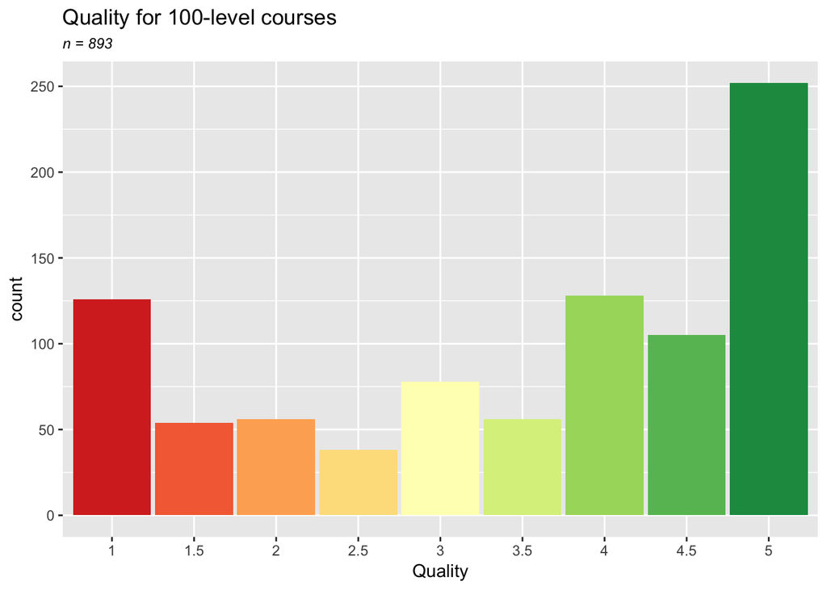

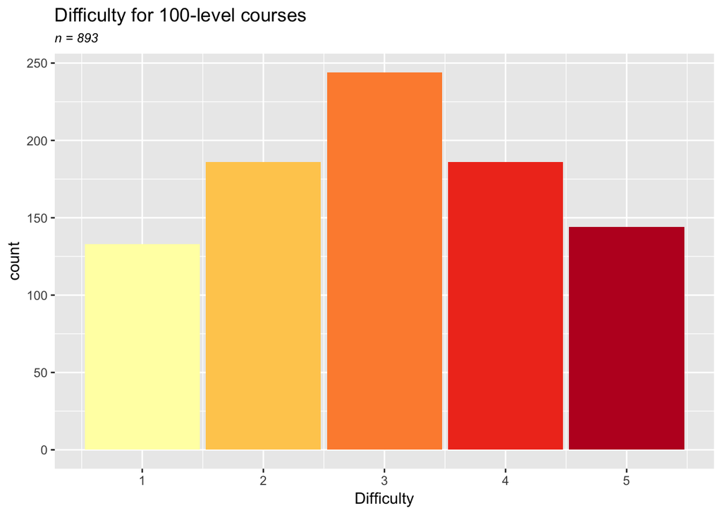

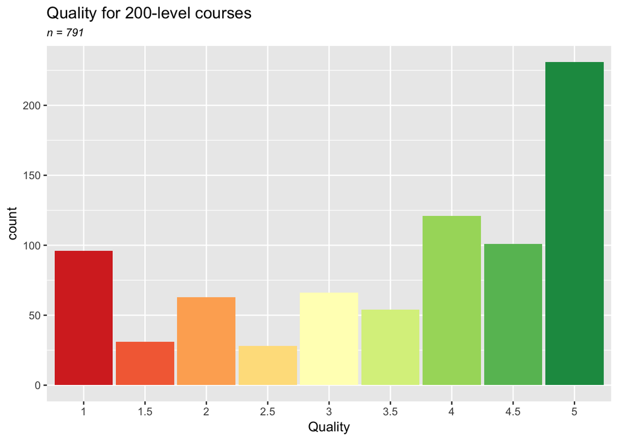

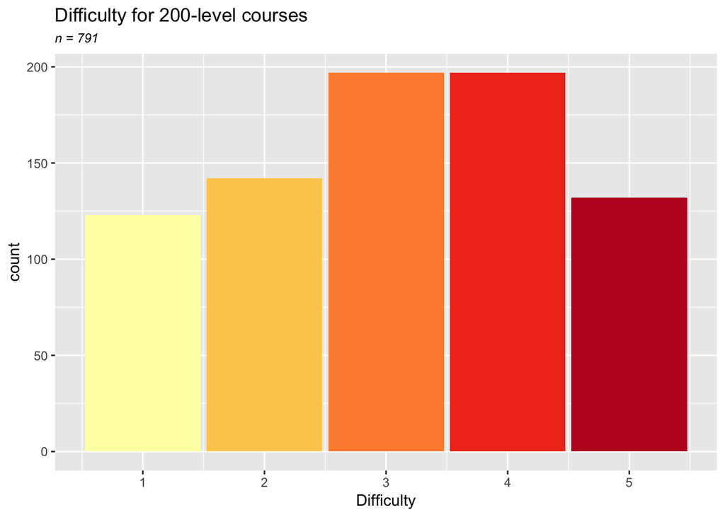

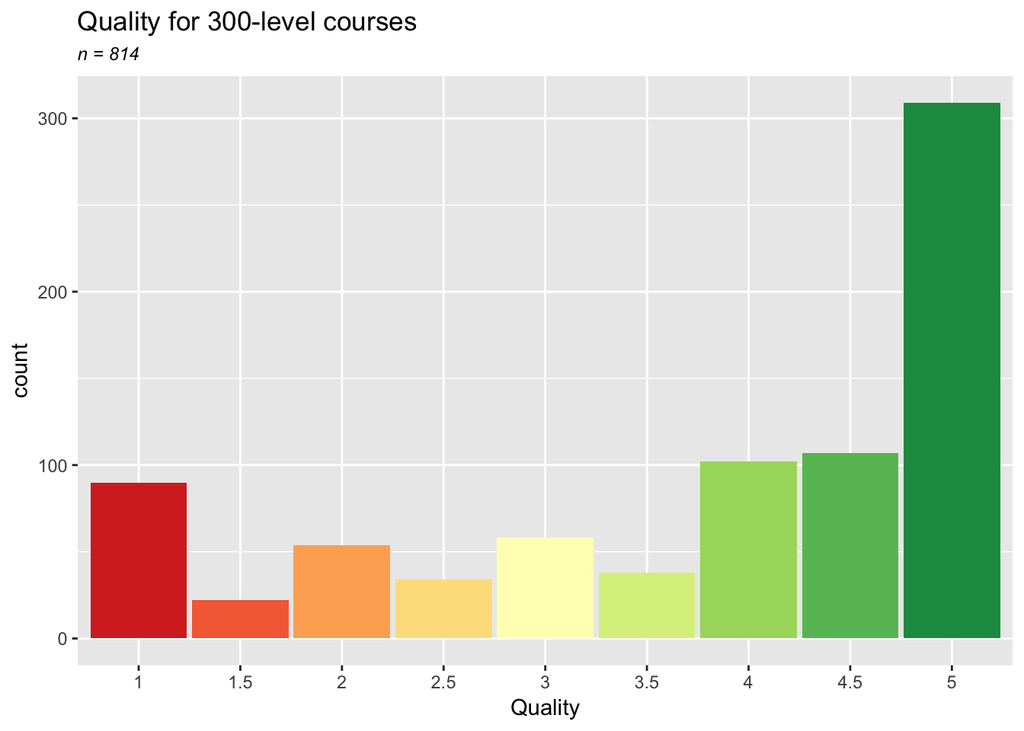

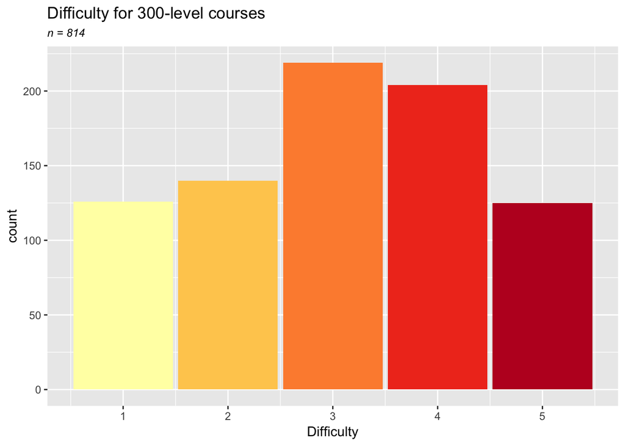

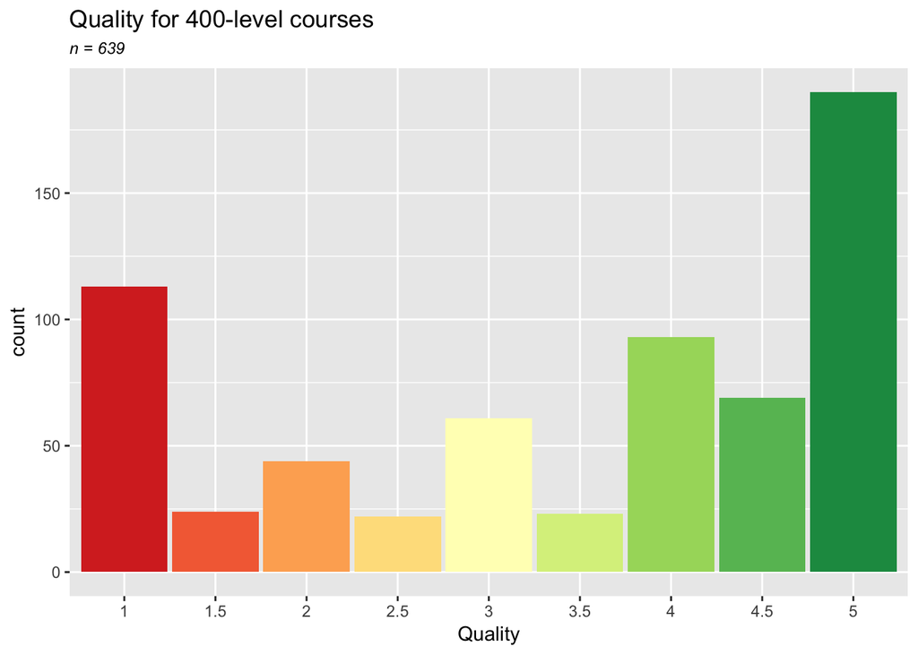

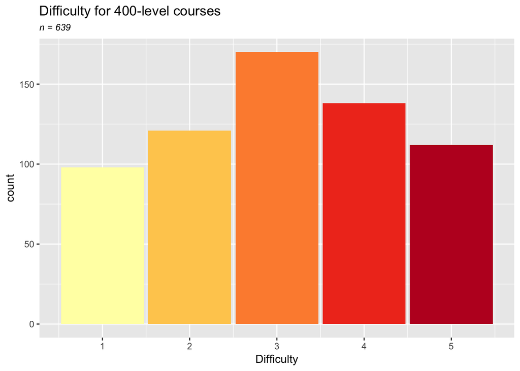

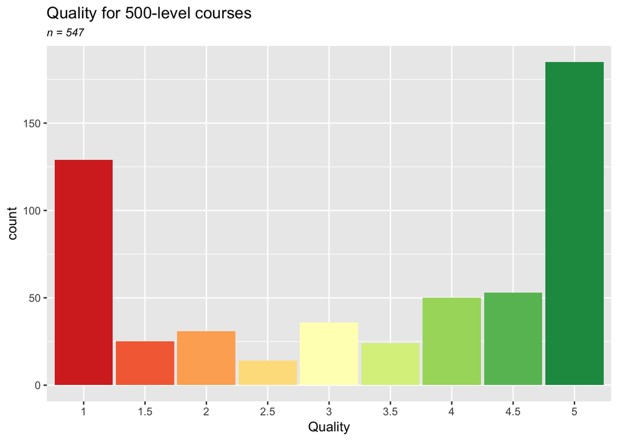

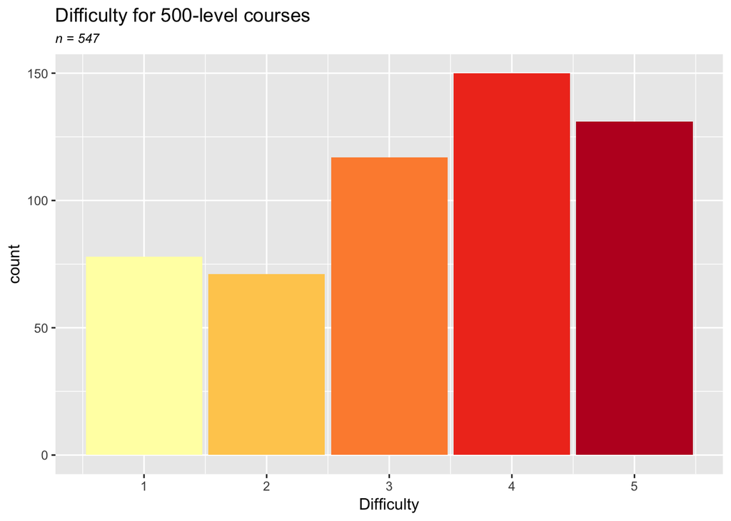

```r
for (x in sort(unique(professor_ratings$Course_Level[professor_ratings$Course_Level > 0]))) {
  ratings_by_level <- professor_ratings %>%
    filter(!is.na(Course_Level) & Course_Level == x)

  if (nrow(ratings_by_level) < 10) { # `Course_Level`s with less than ten reviews is not worthy of a visualization, sorry
    next
  }

  print(ratings_by_level %>%
    ggplot(aes(x = as.factor(Quality), fill = as.factor(Quality))) +
      geom_bar(width = 0.95) +
      labs(title = paste0("Quality for ", x, "-level courses"), subtitle = paste0("n = ", nrow(ratings_by_level)), x = "Quality") +
      theme(legend.position="none",
            plot.subtitle = element_text(size=9, face="italic")) +
      scale_fill_brewer(palette = "RdYlGn"))

  print(ratings_by_level %>%
    ggplot(aes(x = Difficulty, fill = as.factor(Difficulty))) +
      geom_bar(width = 0.95) +
      labs(title = paste0("Difficulty for ", x, "-level courses"), subtitle = paste0("n = ", nrow(ratings_by_level))) +
      theme(legend.position="none",
            plot.subtitle = element_text(size=9, face="italic")) +
      scale_fill_brewer(palette = "YlOrRd"))
}
```

## That’s great, but what about for *all* the courses?

Alright, let’s start answering some questions: are a majority of the RateMyProfessor reviews inherently negative or positive for *all* Illinois Tech courses (I guess specifically with respect to the most-recent 20 reviews for each professor). A very simple bar plot below shows that, actually… (drumroll please)

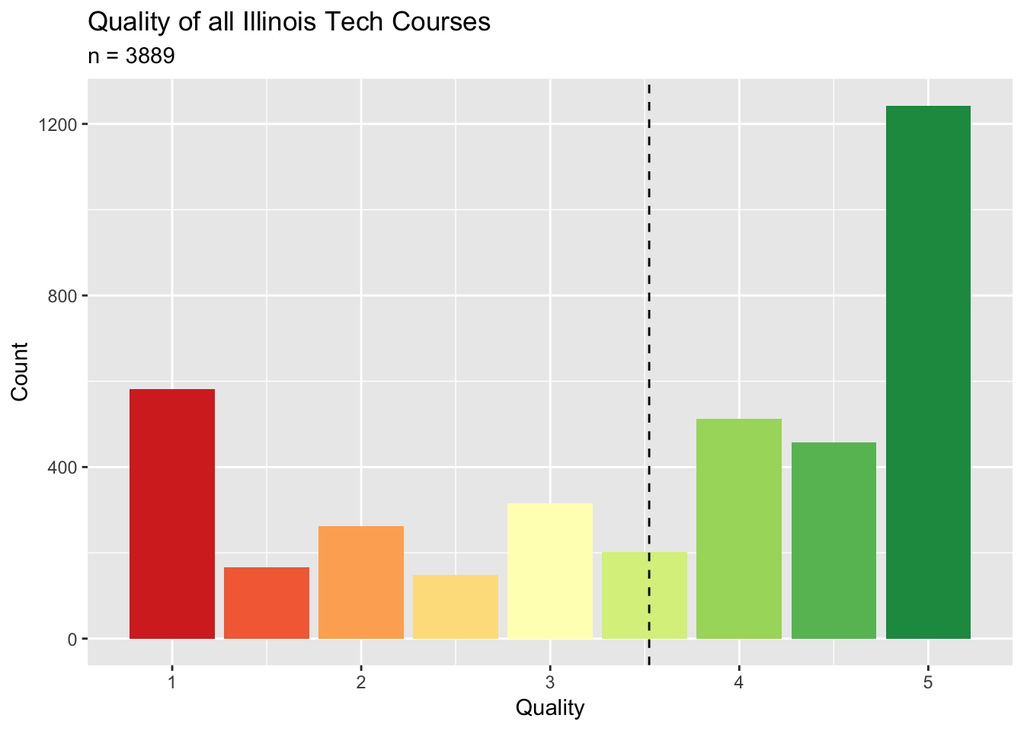

```r
professor_ratings %>%
  ggplot(aes(x = Quality, fill = as.factor(Quality))) +
    geom_bar(width = 0.45) +
    scale_fill_brewer(palette = "RdYlGn") +
    theme(legend.position = "none") +
    labs(title = paste0("Quality of all Illinois Tech Courses"),
         subtitle = paste0("n = ", nrow(professor_ratings)),
         x = "Quality",
         y = "Count") +
    geom_vline(aes(xintercept = mean(Quality)), col = 'black', linetype = "dashed")
```

```r
average_quality <- mean(professor_ratings$Quality)
average_quality
```

```
## [1] 3.523528
```

```r
median_quality <- median(professor_ratings$Quality)
median_quality
```

```
## [1] 4
```

```r
t.test(professor_ratings$Quality, mu = 3, alternative="greater")
```

```
##
##  One Sample t-test
##
## data:  professor_ratings$Quality
## t = 22.085, df = 3888, p-value < 2.2e-16
## alternative hypothesis: true mean is greater than 3
## 95 percent confidence interval:
##  3.484527      Inf
## sample estimates:
## mean of x
##  3.523528
```

And since we can reuse the code pretty easily, let’s also do the same visualization for course difficulty!

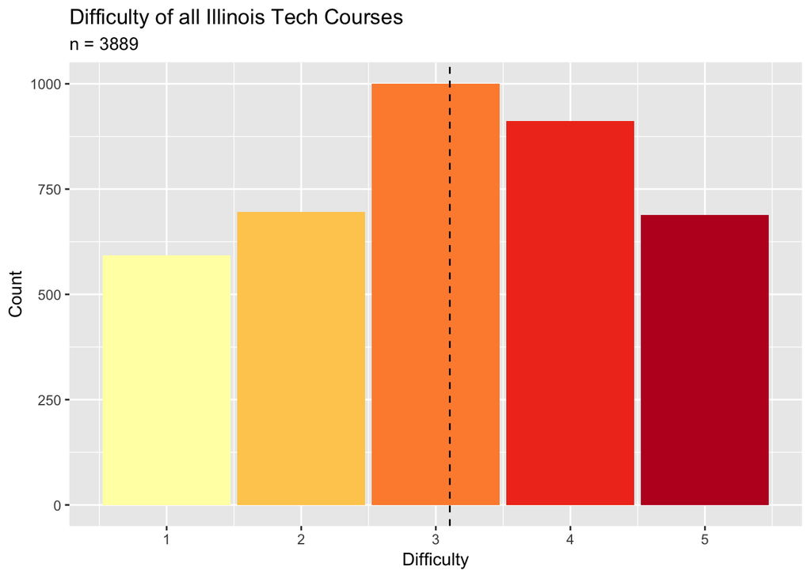

```r
professor_ratings %>%
  ggplot(aes(x = Difficulty, fill = as.factor(Difficulty))) +
    geom_bar(width = 0.95) +
    scale_fill_brewer(palette = "YlOrRd") +
    theme(legend.position = "none") +
    labs(title = paste0("Difficulty of all Illinois Tech Courses"),
         x = "Difficulty",
         y = "Count",
         subtitle = paste0("n = ", nrow(professor_ratings))) +
    geom_vline(aes(xintercept = mean(Difficulty)), col = 'black', linetype = "dashed")
```

```r
average_difficulty <- mean(professor_ratings$Difficulty)
average_difficulty
```

```
## [1] 3.10414
```

```r
median_difficulty <- median(professor_ratings$Difficulty)
median_difficulty
```

```
## [1] 3
```

## What’s correlated to `Quality`?

```r
## `QUALITY` CORRELATION MATRIX
cor(sapply(professor_ratings[, c(4:5, 8:9, 16:37)], as.numeric))[, 1] # just taking columns that are not characters
```

```
##                      Quality                   Difficulty
##                  1.000000000                 -0.428856696
##                   NumHelpful                NumNotHelpful
##                 -0.135445791                  0.007843183
##                Course_Number                 Course_Level
##                 -0.019340207                 -0.021574429
##             TAG_TOUGH_GRADER      TAG_GIVES_GOOD_FEEDBACK
##                 -0.254780991                  0.189856918
##                TAG_RESPECTED        TAG_GET_READY_TO_READ
##                  0.207672687                 -0.049904148
##    TAG_PARTICIPATION_MATTERS         TAG_LOTS_OF_HOMEWORK
##                  0.070390910                 -0.079792181
##            TAG_INSPIRATIONAL    TAG_BEWARE_OF_POP_QUIZZES
##                  0.157573035                 -0.033559449
## TAG_ACCESSIBLE_OUTSIDE_CLASS           TAG_SO_MANY_PAPERS
##                  0.112553834                 -0.050331808
##   TAG_CLEAR_GRADING_CRITERIA                TAG_HILARIOUS
##                  0.137597682                  0.082707455
##               TAG_TEST_HEAVY     TAG_GRADED_BY_FEW_THINGS
##                 -0.113515696                 -0.091049370
##         TAG_AMAZING_LECTURES                   TAG_CARING
##                  0.212460100                  0.169715946
##             TAG_EXTRA_CREDIT           TAG_GROUP_PROJECTS
##                  0.056268503                 -0.040084586
##            TAG_LECTURE_HEAVY                     GoodProf
##                 -0.118789381                  0.903940284
```

Now visually exploring some parameters from the correlation matrix above…

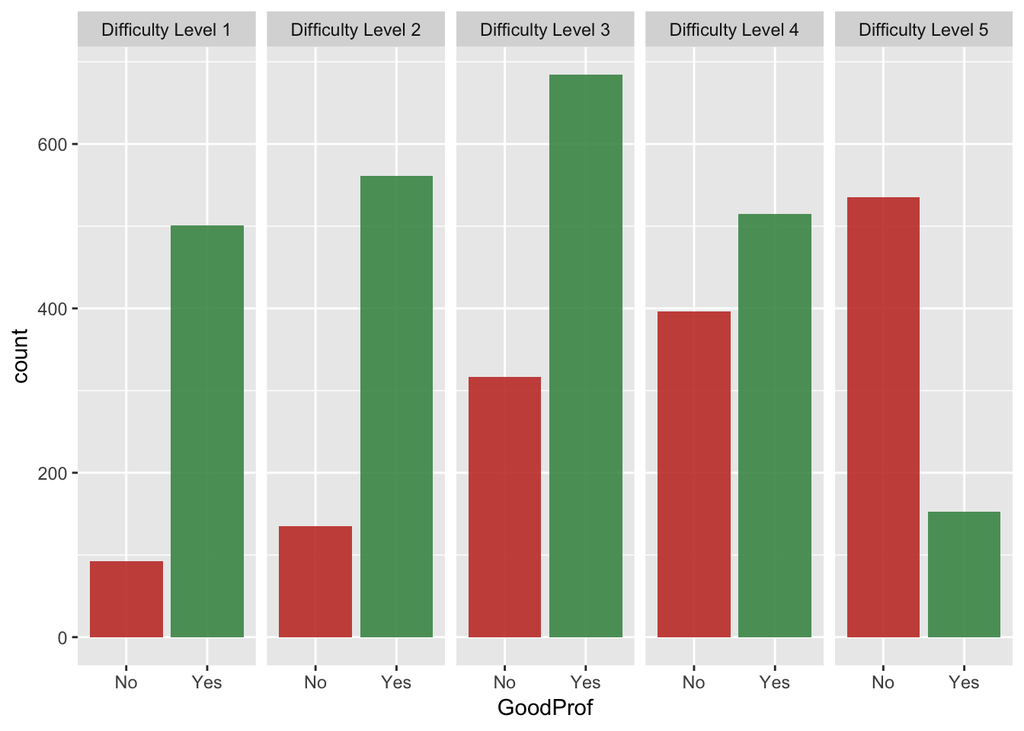

```r
# GoodProf vs. Difficulty
professor_ratings %>%
  mutate(Difficulty = paste0("Difficulty Level ", Difficulty)) %>%
  ggplot(aes(x = GoodProf, fill = GoodProf)) +
    geom_bar(alpha = 0.9) +
    scale_x_discrete(labels=c("No", "Yes")) +
    facet_wrap(~Difficulty, ncol = 5) +
    scale_fill_manual(values = c("#C73F33", "#479557"), guide = FALSE)
```

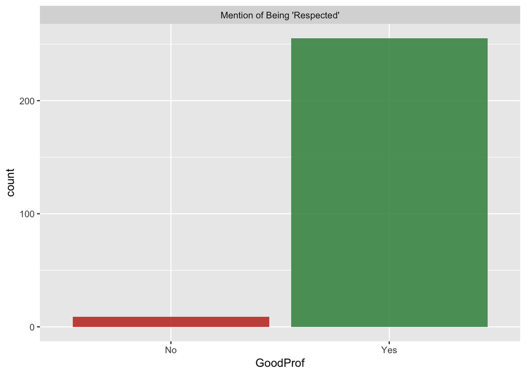

```r
# GoodProf vs. RESPECTED
professor_ratings %>%
  filter(TAG_RESPECTED == 1) %>%
  mutate(TAG_RESPECTED = ifelse(TAG_RESPECTED == 1, "Mention of Being 'Respected'", "No Mention of Being 'Respected'")) %>%
  ggplot(aes(x = GoodProf, fill = GoodProf)) +
    geom_bar(alpha = 0.9) +
    scale_x_discrete(labels=c("No", "Yes")) +
    facet_wrap(~TAG_RESPECTED, ncol = 5) +
    scale_fill_manual(values = c("#C73F33", "#479557"), guide = FALSE)
```

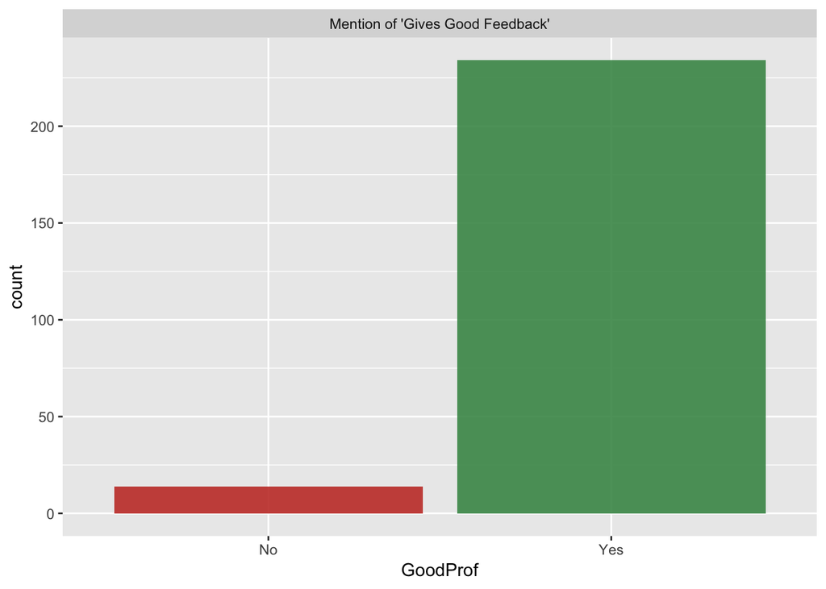

```r
# GoodProf vs. GIVES_GOOD_FEEDBACK
professor_ratings %>%
  filter(TAG_GIVES_GOOD_FEEDBACK == 1) %>%
  mutate(TAG_GIVES_GOOD_FEEDBACK = ifelse(TAG_GIVES_GOOD_FEEDBACK == 1, "Mention of 'Gives Good Feedback'", "No Mention of 'Gives Good Feedback'")) %>%
  ggplot(aes(x = GoodProf, fill = GoodProf)) +
    geom_bar(alpha = 0.9) +
    scale_x_discrete(labels=c("No", "Yes")) +
    facet_wrap(~TAG_GIVES_GOOD_FEEDBACK, ncol = 5) +
    scale_fill_manual(values = c("#C73F33", "#479557"), guide = FALSE)
```

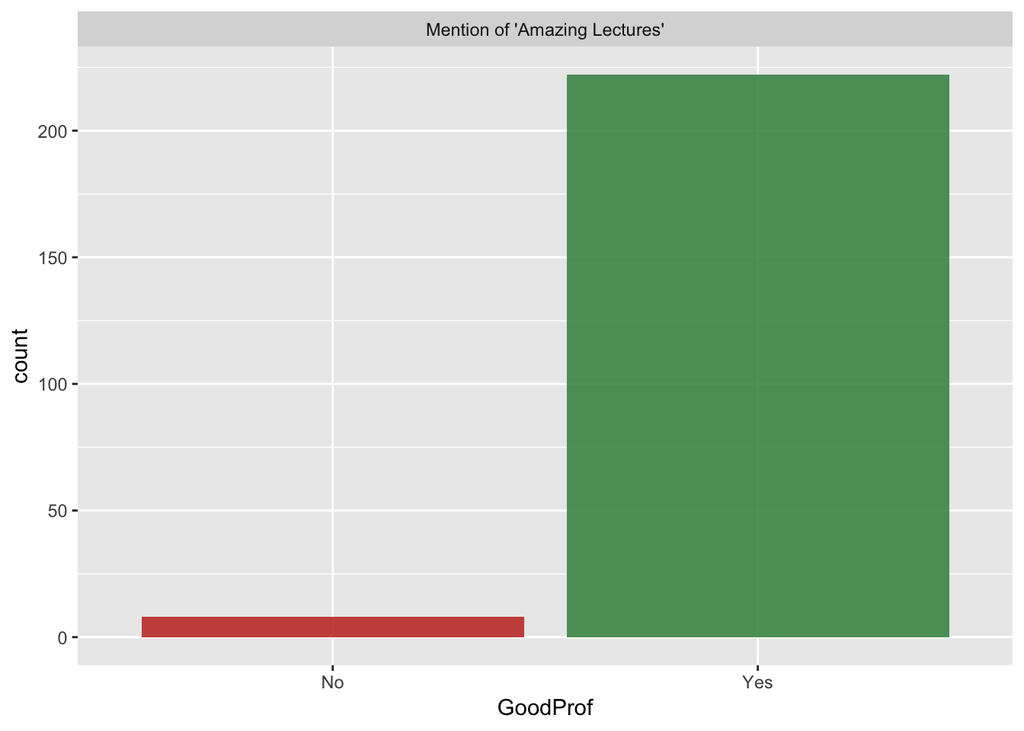

```r
# GoodProf vs. AMAZING_LECTURES
professor_ratings %>%
  filter(TAG_AMAZING_LECTURES == 1) %>%
  mutate(TAG_AMAZING_LECTURES = ifelse(TAG_AMAZING_LECTURES == 1, "Mention of 'Amazing Lectures'", "No Mention of 'Amazing Lectures'")) %>%
  ggplot(aes(x = GoodProf, fill = GoodProf)) +
    geom_bar(alpha = 0.9) +
    scale_x_discrete(labels=c("No", "Yes")) +
    facet_wrap(~TAG_AMAZING_LECTURES, ncol = 5) +
    scale_fill_manual(values = c("#C73F33", "#479557"), guide = FALSE)
```

## RMP, meet NLP

Even though I’ve already made my point that it’s not all negative (AKA the RMP reviews I pulled are actually much more positive than negative), it’s hard to summarize an entire course’s worth of thoughts into a single `Quality` number. The most useful part of RMP’s system is the extensive comments reviewers leave for each course. If only there was a way to do some sort of “sentiment analysis” on the comments or something…

Yup – let’s do this. I’m not an NLP-expert by any means, I truly only have experience working with Stanford’s CoreNLP package during my REU last summer, but since the installation is oh-so-very broken on my macOS architecture (Java 8 installation will be the death of me) and I would rather not boot into my Windows Virtual Machine at this moment, I’ll be going with an alternative: `sentimentr`, which is an effective augmented dictionary lookup to determine a numerical sentiment for a sentence. The more negative a rating is, the more negative the sentiment, and vice versa for positive. Do our results for comment sentiment still hold up to our conclusions from above (spoiler warning: yes).

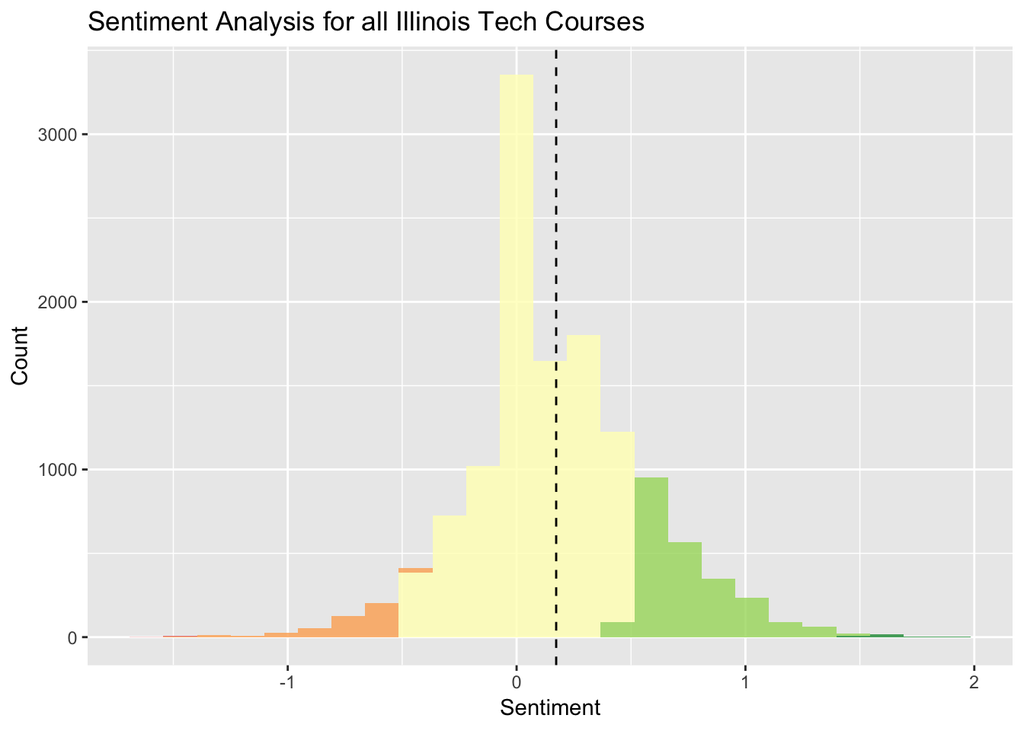

```r
comment_sentiments <- sentiment(professor_ratings$Comments)

comment_sentiments %>%
  ggplot(aes(x = sentiment, fill = as.factor(round(sentiment, 0)))) +
    geom_histogram(bins = 25, alpha = 0.8) +
    scale_fill_brewer(palette = "RdYlGn") +
    theme(legend.position = "none") +
    labs(title = paste0("Sentiment Analysis for all Illinois Tech Courses"),
         x = "Sentiment",
         y = "Count") +
    geom_vline(aes(xintercept = mean(sentiment)), col = 'black', linetype = "dashed")
```

```r
average_sentiment <- mean(comment_sentiments$sentiment)
average_sentiment
```

```
## [1] 0.1729943
```

```r
median_sentiment <- median(comment_sentiments$sentiment)
median_sentiment
```

```
## [1] 0.125
```

```r
extract_sentiment_terms(professor_ratings$Comments)
```

```
##        element_id sentence_id           negative
##     1:          1           1
##     2:          2           1
##     3:          2           2        challenging
##     4:          3           1
##     5:          3           2        challenging
##    ---
## 12921:       3888           2 mandatory,tempting
## 12922:       3888           3
## 12923:       3888           4
## 12924:       3889           1           too much
## 12925:       3889           2
##                                   positive
##     1:                     great,professor
##     2: professor,clear,helpful,outstanding
##     3: advanced,organic,interesting,fairly
##     4:                     great,professor
##     5:                                 fun
##    ---
## 12921:           attendance,understand,ace
## 12922:                like,understand,easy
## 12923:                              nicest
## 12924:                           professor
## 12925:                  passionate,teacher
```

```r
# RUN THIS CODE TO GET EXACT COMMENT POLARITY
#professor_ratings$Comments %>%
#  sentiment_by(by = NULL) %>%
#  highlight()

t.test(comment_sentiments$sentiment, mu = 0, alternative="greater")
```

```
##
##  One Sample t-test
##
## data:  comment_sentiments$sentiment
## t = 50.487, df = 12924, p-value < 2.2e-16
## alternative hypothesis: true mean is greater than 0
## 95 percent confidence interval:
##  0.1673577       Inf
## sample estimates:
## mean of x
## 0.1729943
```

## Creating the Final Dataset

Let’s go ahead and add in our NLP results to the master dataframe.

```r
## MEAN OF SENTIMENTS PER RATING ##
rating_sentiments <- comment_sentiments %>%
  select(-c("sentence_id")) %>% # drop columns
  group_by(element_id) %>% # group by
  mutate(sentiment = mean(sentiment)) %>% # mean sentiment
  mutate(word_count = sum(word_count, na.rm = TRUE)) %>% # total word count
  unique() # remove multiple element_ids with the same value

## MERGE DATAFRAMES ##
professor_ratings$element_id <- seq(1:nrow(professor_ratings))
ratings_and_sentiments <- merge(professor_ratings, rating_sentiments, by = "element_id")

## DROP SOME ROWS ##
ratings_and_sentiments <- ratings_and_sentiments %>%
  filter(Course_Level > 0)
ratings_and_sentiments$Course_Level <- as.factor(ratings_and_sentiments$Course_Level)
head(ratings_and_sentiments)
```

```
##   element_id      Name  Course  Rating Quality Difficulty
## 1          1 Stagliano CHEM237 awesome     5.0          3
## 2          2 Stagliano CHEM531 awesome     5.0          3
## 3          3 Stagliano CHEM124 awesome     5.0          4
## 4          5 Stagliano CHEM237 awesome     4.5          4
## 5          7 Stagliano  CHM237    poor     2.0          3
## 6          8 Stagliano CHEM125    good     4.0          3
##                                                                                                                                                                                          Comments
## 1                                                                                                                                                                                 Great Professor
## 2 Professor Stagliano was very clear, helpful, and an outstanding communicator.  He made the subject of advanced organic chemistry very interesting, although it was a fairly challenging course.
## 3                                 Great Professor.  Challenging, but made it fun.  Taught very clearly and well.  Take his class if you want to learn.  Don't take them if you just want a grade.
## 4                                                                              Very approachable outside of the classroom.  Materials is hard in general, and he really knows the topics covered.
## 5                                                                                                                                                                     needs to learn how to write
## 6                                                                                                                                                                        he is an amazing teacher
##   Tags NumHelpful NumNotHelpful Grade WouldTakeAgain TextbookUsed
```

[output cut: 62 more lines]

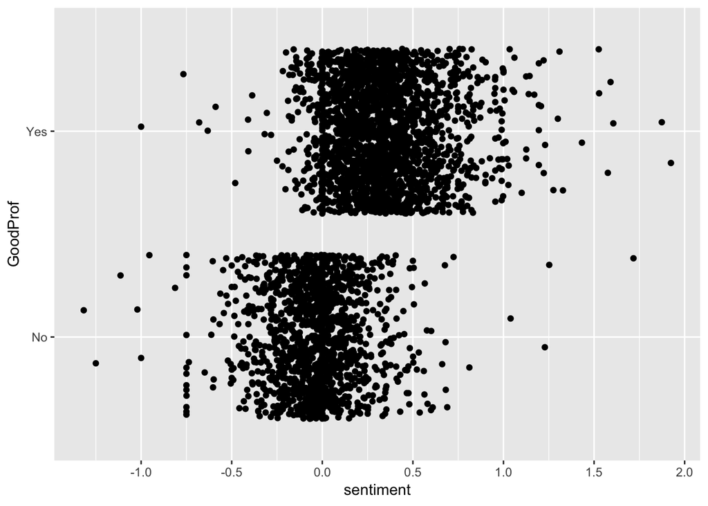

```r
ratings_and_sentiments %>%
  ggplot(aes(x = sentiment, y = GoodProf)) +
    geom_jitter() +
    scale_x_continuous(breaks=seq(-2, 2, 0.5)) +
    scale_y_discrete(labels=c("No", "Yes"))
```

# “Wow, excellent work so far, but what do you know about modeling?”

Well thank you! Let’s get into it: I’d ideally like to create two models - one that can predict based off of the `GoodProf` category (which is either yes or no) and one predicting `Quality` (anywhere from 1.0 to 5.0 in increments of 0.5).

For our first model, since we are dealing with a binary categorical variable, I use the lasso shrinkage method on a standrad logistic regression to be able to filter out any of our numerous parameters that might not be significantly contributing to our model, and then throw only the most significant of parameters into a simple model that is easy to interpret and understand when looking into future modeling solutions. A useless model would predict `GoodProf` correctly about 50% of the time (simple coin toss), a model that just chooses the majority class would get it right ~62.07% of the time in this instance. I like to think that any model above 70% accuracy holds some weight and anything above 80% deserves a bit of respect. With that, what does this model achieve?

For the last model, I use a random forest to predict `Quality`, which I expect will have a bit worse accuracy than the above model given the number of possible choices increases from 2 to 9. I have a sweet spot for random forests - they are simple to understand, simple to implement, and simple to prune (because you technically don’t have to). Random forests are keen to detecting patterns between all of our different parameters when assigning a `Quality` score, which I believe is prevalent in the data based off of the correlation matrix and visualizations above. I’ll only be evaluating the model based off of the parameters kept through lasso over many trials. Since this is a regression-based random forest, I’ll be evaluating our `Quality` model using RMSE, ensuring we weight larger errors a bit more, supplied through bootstrapping with 100 resampling iterations, which gives us the expected out-of-sample average amount of error within our estimates.

```r
training <- createDataPartition(ratings_and_sentiments$element_id, p = 0.8, list = FALSE, times = 1)
train_control <- trainControl(method = "boot", number = 100)

# Lasso with Logistic Regression
# Perform a lasso regression using the glmnet package specifying a vector of 100 values of lambda for tuning.
x <- model.matrix(GoodProf ~ Difficulty + NumHelpful + NumNotHelpful + Date + Course_Level + TAG_TOUGH_GRADER + TAG_GIVES_GOOD_FEEDBACK + TAG_RESPECTED + TAG_GET_READY_TO_READ + TAG_PARTICIPATION_MATTERS + TAG_LOTS_OF_HOMEWORK + TAG_INSPIRATIONAL + TAG_BEWARE_OF_POP_QUIZZES + TAG_ACCESSIBLE_OUTSIDE_CLASS + TAG_SO_MANY_PAPERS + TAG_CLEAR_GRADING_CRITERIA + TAG_HILARIOUS + TAG_TEST_HEAVY + TAG_GRADED_BY_FEW_THINGS + TAG_AMAZING_LECTURES + TAG_CARING + TAG_EXTRA_CREDIT + TAG_GROUP_PROJECTS + TAG_LECTURE_HEAVY + word_count + sentiment, data = ratings_and_sentiments)[ , -1]
y <- ratings_and_sentiments$GoodProf
grid <- 10^seq(10,-2,length=100)
# alpha = 1 for lasso
lasso.mod <- glmnet(x[ training, ], y[training], alpha=1, lambda=grid, family="binomial")

# Using cross-validation to determine the minimum value for lambda
cv.out = cv.glmnet(x[training ,], y[training], alpha=1, nfolds = 10, family="binomial")
bestlam = cv.out$lambda.min
print(paste0("Minimum Value for Lambda: ", bestlam)) # minimum lambda
```

```
## [1] "Minimum Value for Lambda: 0.00198985417341538"
```

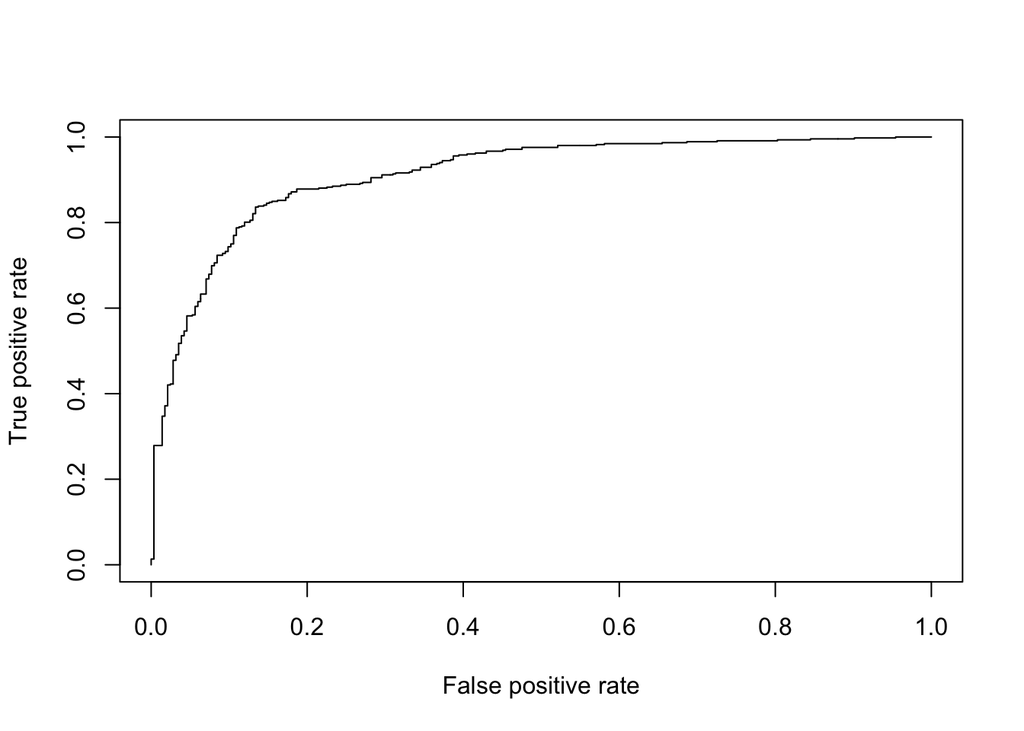

```r
## CALCULATE AUC
lasso_model_prediction <- predict(cv.out, newx = x[-training,], type = "response")
lasso_prediction_object <- prediction(lasso_model_prediction, y[-training])
prf <- performance(lasso_prediction_object, measure = "tpr", x.measure = "fpr")
plot(prf)
```

```r
auc <- performance(lasso_prediction_object, measure = "auc")
auc <- auc@y.values[[1]]
auc
```

```
## [1] 0.910554
```

```r
out <- glmnet(x, y, alpha = 1, lambda=grid, family="binomial")
lasso.coef <- predict(out, type="coefficients", s=bestlam)
coef(cv.out)
```

```
## 32 x 1 sparse Matrix of class "dgCMatrix"
##                                           1
## (Intercept)                    1.586896e+00
## Difficulty                    -4.232842e-01
## NumHelpful                    -2.838861e-02
## NumNotHelpful                  1.664417e-03
## Date                          -3.361324e-05
## Course_Level200                .
## Course_Level300                1.293125e-01
## Course_Level400                .
## Course_Level500                .
## Course_Level600                .
## Course_Level700                .
## TAG_TOUGH_GRADER1             -7.943132e-01
## TAG_GIVES_GOOD_FEEDBACK1       1.012520e+00
## TAG_RESPECTED1                 1.375135e+00
## TAG_GET_READY_TO_READ1        -7.977348e-02
## TAG_PARTICIPATION_MATTERS1     .
## TAG_LOTS_OF_HOMEWORK1         -1.305668e-01
## TAG_INSPIRATIONAL1             4.459540e-01
## TAG_BEWARE_OF_POP_QUIZZES1     .
## TAG_ACCESSIBLE_OUTSIDE_CLASS1  6.723252e-02
## TAG_SO_MANY_PAPERS1            .
## TAG_CLEAR_GRADING_CRITERIA1    .
## TAG_HILARIOUS1                 2.094627e-01
## TAG_TEST_HEAVY1               -1.504256e-01
## TAG_GRADED_BY_FEW_THINGS1     -6.933705e-01
## TAG_AMAZING_LECTURES1          8.011840e-01
## TAG_CARING1                    6.518486e-01
## TAG_EXTRA_CREDIT1              .
## TAG_GROUP_PROJECTS1           -3.127776e-01
## TAG_LECTURE_HEAVY1            -3.131132e-01
## word_count                     .
## sentiment                      5.383916e+00
```

```r
# What is out-of-sample test set performance?
lasso.pred <- predict(lasso.mod, s = bestlam, newx = x[-training,])
fitted.results <- ifelse(lasso.pred >= 0.5, 1, 0)
test_set <- as.numeric(y[-training]) - 1
accuracy <- mean(fitted.results == test_set)
print(paste0("Out-of-sample test set accuracy: ", round(accuracy, 4)))
```

```
## [1] "Out-of-sample test set accuracy: 0.841"
```

```r
## RANDOM FOREST ##
rf <- train(Quality ~ Difficulty + NumHelpful + NumNotHelpful + Date + Course_Level + TAG_TOUGH_GRADER + TAG_GIVES_GOOD_FEEDBACK + TAG_RESPECTED + TAG_INSPIRATIONAL + TAG_HILARIOUS + TAG_TEST_HEAVY + TAG_GRADED_BY_FEW_THINGS + TAG_AMAZING_LECTURES + TAG_CARING + TAG_GROUP_PROJECTS + TAG_LECTURE_HEAVY + sentiment, data = ratings_and_sentiments, trControl = train_control, method = "ranger")
print(rf)
```

```
## Random Forest
##
## 3692 samples
##   17 predictor
##
## No pre-processing
## Resampling: Bootstrapped (100 reps)
## Summary of sample sizes: 3692, 3692, 3692, 3692, 3692, 3692, ...
## Resampling results across tuning parameters:
##
##   mtry  splitrule   RMSE       Rsquared   MAE
##    2    variance    1.0175305  0.5841943  0.8485239
##    2    extratrees  1.1550141  0.4799708  0.9833780
##   12    variance    0.9900288  0.5527578  0.7601806
##   12    extratrees  0.9714489  0.5684941  0.7496626
##   22    variance    1.0118158  0.5343215  0.7741610
##   22    extratrees  0.9918221  0.5512334  0.7606961
##
## Tuning parameter 'min.node.size' was held constant at a value of 5
## RMSE was used to select the optimal model using the smallest value.
## The final values used for the model were mtry = 12, splitrule =
##  extratrees and min.node.size = 5.
```

```r
print(rf$results[rf$results$RMSE == min(rf$results$RMSE), ]) # what's the minimum RMSE our tree configuration can get?
```

```
##   mtry min.node.size  splitrule      RMSE  Rsquared       MAE     RMSESD
## 4   12             5 extratrees 0.9714489 0.5684941 0.7496626 0.01620544
##   RsquaredSD      MAESD
## 4 0.01555111 0.01195745
```

```r
# mtry = Number of variables available for splitting at each tree node.
# min.node.size = Number of entries in each node, minimum.
# splitrule extratrees = selects a cut-point at random.
```

# Findings

- Using IMDb’s True Bayesian Rating scale, we discovered that the lowest-rated course at Illinois Tech is CS 553 with the highest-rated course being HUM 380. Reading the review comments for each, it’s clear to see just how extreme these two cases are.
- With our sample of more-recent RateMyProfessor reviews for each professor at Illinois Institute of Technology, we find with p = 0.01 statistical significance that the average Quality is greater than 3 (neutral) and the average sentiment of comments is greater than 0 (neutral), supporting the hypothesis that RateMyProfessor reviews are not inherently more negative than positive in both quality rating and comment sentiment.
- Our logistic regression model correctly predicts whether the review details indiciate the professor recieved a Quality greater than or equal to 3.5 or not with about ~82-86% accuracy on test data.
- Our random forest model predicts `Quality` within an average RMSE of ~0.98 units.

# Future Work

There are definitely a lot of limitations here that affect the overall power of the findings. To alleviate this, future work should:

- Work to scrape *all* of the ratings from each professor’s RMP page, not just the most-recent 20. Doing this will have us work with the full population of ratings, not just a select sample.
- Do more preprocessing with columns such as `Grade` and `ForCredit` that have mostly `NA` values in them - although they are sparse, chances are that a good grade received in the course can predict a more positive review.
- Improve the model quality by further parameter tuning and weighting. Doing the suggestions above might be effective enough in model improvement, however, as more data tends to lend to a more confident model.
- Deal with `Course`s that have only numbers in them in a more elegant way rather than just marking them as -1 in the `Course_Number` and `Course_Level`.
- It could benefit the model performance to standardize sentiments so more extreme sentiments are evident compared to mostly neutral ones. See if that does anything for the model results.
- Incorporate the model into other schools’ RMP pages - do the results still hold up, or are they only specific to Illinois Institute of Technology course reviews?
- Explore the hypothesis that students tend to only write “extreme” reviews for RateMyProfessor (either really good or really bad quality) and not for professors they felt more neutral on.
- See how different RMP reviews are compared to the mandatory course reviews conducted through Illinois Tech’s own system.
- Explore common keywords in reviews and see how these keywords relate to assigned `Quality` score in any way.